# SummarizedExperiment

[Michael Love](http://mikelove.github.io)

When I previously covered objects, we learned about ExpressionSet, and mentioned that a similarly shaped object is SummarizedExperiment. By shape, I refer to the [3 tables](https://www.ncbi.nlm.nih.gov/pmc/articles/PMC4509590/figure/F2/) that make up the object, one for the data, one for the sample information, and one for the feature/row information. In SummarizedExperiment, these are called `assay`, `colData` and `rowData` or `rowRanges` (more on this below). This generalizes the language that was used for ExpressionSet, so they apply to more types of datasets (not just gene expression: `exprs`, `phenoData`, and `featureData`).

It helps to start by making a small toy SummarizedExperiment, to see how the pieces come together.

```r
library(SummarizedExperiment)
colData <- data.frame(sample=factor(1:6),
                      condition=factor(c("A","A","B","B","C","C")),
                      treated=factor(rep(0:1,3)))
colData
```

```
##   sample condition treated
## 1      1         A       0
## 2      2         A       1
## 3      3         B       0
## 4      4         B       1
## 5      5         C       0
## 6      6         C       1
```

So far, it is similar to ExpressionSet. The key difference is that the rows of a SummarizedExperiment can correspond to GRanges. If we don’t have ranges, we can just put a table on the side of the SummarizedExperiment by specifying `rowData`.

I will show in the example though how to provide `rowRanges`. Let’s use the first 10 genes in the Ensembl database for human:

```r
library(EnsDb.Hsapiens.v86)
txdb <- EnsDb.Hsapiens.v86
g <- genes(txdb)
g <- keepStandardChromosomes(g, pruning.mode="coarse")
rowRanges <- g[1:10]
```

We will make up some simulated “expression” measurements, and then store these in the SummarizedExperiment. I call `list` so I can name the matrix, otherwise it would not be named.

```r
exprs <- matrix(rnorm(6 * 10), ncol=6, nrow=10)
se <- SummarizedExperiment(assay=list("exprs"=exprs),
                           colData=colData,
                           rowRanges=rowRanges)
se
```

```
## class: RangedSummarizedExperiment
## dim: 10 6
## metadata(0):
## assays(1): exprs
## rownames(10): ENSG00000223972 ENSG00000227232 ... ENSG00000238009 ENSG00000239945
## rowData names(6): gene_id gene_name ... symbol entrezid
## colnames: NULL
## colData names(3): sample condition treated
```

We see this object has one named matrix. It could have others, and in that case you could access the first with `assay` and in general by name, e.g. `assays(se)[["exprs"]]`

```r
assayNames(se)
```

```
## [1] "exprs"
```

Finally, if we wanted to add data onto the rows, for example, the score of a test on the matrix data, we use the metadata columns function, or `mcols`:

```r
mcols(se)$score <- rnorm(10)
mcols(se)
```

```
## DataFrame with 10 rows and 7 columns
##                         gene_id    gene_name           gene_biotype seq_coord_system       symbol
##                     <character>  <character>            <character>      <character>  <character>
## ENSG00000223972 ENSG00000223972      DDX11L1 transcribed_unproces..       chromosome      DDX11L1
## ENSG00000227232 ENSG00000227232       WASH7P unprocessed_pseudogene       chromosome       WASH7P
## ENSG00000278267 ENSG00000278267    MIR6859-1                  miRNA       chromosome    MIR6859-1
## ENSG00000243485 ENSG00000243485    MIR1302-2                lincRNA       chromosome    MIR1302-2
## ENSG00000237613 ENSG00000237613      FAM138A                lincRNA       chromosome      FAM138A
## ENSG00000268020 ENSG00000268020       OR4G4P unprocessed_pseudogene       chromosome       OR4G4P
## ENSG00000240361 ENSG00000240361      OR4G11P unprocessed_pseudogene       chromosome      OR4G11P
## ENSG00000186092 ENSG00000186092        OR4F5         protein_coding       chromosome        OR4F5
## ENSG00000238009 ENSG00000238009 RP11-34P13.7                lincRNA       chromosome RP11-34P13.7
## ENSG00000239945 ENSG00000239945 RP11-34P13.8                lincRNA       chromosome RP11-34P13.8
##                                       entrezid     score
##                                         <list> <numeric>
## ENSG00000223972 100287596,100287102,727856,... -0.932591
## ENSG00000227232                             NA  1.474378
## ENSG00000278267                      102466751 -2.369093
## ENSG00000243485            105376912,100302278 -1.055737
## ENSG00000237613           654835,645520,641702 -0.749110
## ENSG00000268020                             NA -1.748871
## ENSG00000240361                             NA  0.142127
## ENSG00000186092                          79501  1.238061
## ENSG00000238009                             NA -0.671039
## ENSG00000239945                             NA  0.363201
```

# Using the ranges of a SummarizedExperiment

How does this additional functionality of the `rowRanges` facilitate faster data analysis? Suppose we are working with another data set besides `se` and we find a region of interest on chromsome 1. If we want to pull out the expression data for that region, we just ask for the subset of `se` that overlaps. First we build the query region, and then use the *GRanges* function `overlapsAny` within single square brackets (like you would subset any matrix-like object:

```r
query <- GRanges("1", IRanges(25000,40000))
se.sub <- se[overlapsAny(se, query), ]
```

We could have equivalently used the shorthand code:

```r
se.sub <- se[se %over% query,]
```

We get just three ranges, and three rows of the SummarizedExperiment:

```r
rowRanges(se.sub)
```

```
## GRanges object with 3 ranges and 7 metadata columns:
##                   seqnames      ranges strand |         gene_id   gene_name           gene_biotype
##                      <Rle>   <IRanges>  <Rle> |     <character> <character>            <character>
##   ENSG00000227232        1 14404-29570      - | ENSG00000227232      WASH7P unprocessed_pseudogene
##   ENSG00000243485        1 29554-31109      + | ENSG00000243485   MIR1302-2                lincRNA
##   ENSG00000237613        1 34554-36081      - | ENSG00000237613     FAM138A                lincRNA
##                   seq_coord_system      symbol             entrezid     score
##                        <character> <character>               <list> <numeric>
##   ENSG00000227232       chromosome      WASH7P                 <NA>   1.47438
##   ENSG00000243485       chromosome   MIR1302-2  105376912,100302278  -1.05574
##   ENSG00000237613       chromosome     FAM138A 654835,645520,641702  -0.74911
##   -------
##   seqinfo: 25 sequences from GRCh38 genome
```

```r
assay(se.sub)
```

```
##                       [,1]        [,2]          [,3]        [,4]      [,5]       [,6]
## ENSG00000227232  0.4064710  0.38943462 -1.1082017692  1.29791048 0.9214626 -0.7278540
## ENSG00000243485 -0.7661646  0.04849405  0.0001449229 -0.07394154 0.7530937  0.0268623
## ENSG00000237613  0.2875705 -0.34390321  0.7971469140 -1.86936179 0.5750412 -1.5392133
```

Another useful property is that we know metadata about the chromosomes, and the version of the genome. (If you were not yet aware, the basepair position of a given feature, say gene *XYZ*, will change between versions of the genome, as sequences are added or rearranged — you should also know that the human genome has not been fully sequenced as of 2017, which we will discuss in class.)

```r
seqinfo(se)
```

```
## Seqinfo object with 25 sequences from GRCh38 genome:
##   seqnames seqlengths isCircular genome
##   1         248956422      FALSE GRCh38
##   10        133797422      FALSE GRCh38
##   11        135086622      FALSE GRCh38
##   12        133275309      FALSE GRCh38
##   13        114364328      FALSE GRCh38
##   ...             ...        ...    ...
##   8         145138636      FALSE GRCh38
##   9         138394717      FALSE GRCh38
##   MT            16569      FALSE GRCh38
##   X         156040895      FALSE GRCh38
##   Y          57227415      FALSE GRCh38
```

# Downloading SummarizedExperiment data

We previously introduced the computational project, called [recount2](https://jhubiostatistics.shinyapps.io/recount/), which performs a basic summarization of public data sets with gene expression data. We will use data from *recount2* again.

This dataset contains RNA-seq samples from human airway epithelial cell cultures. The paper is [here](https://www.ncbi.nlm.nih.gov/pubmed/25706956). The structure of the experiment was that, cell cultures from 6 asthmatic and 6 non-asthmatics donors were treated with viral infection or left untreated (controls). So we have 2 samples (control or treated) for each of the 12 donors.

```r
url <- "http://duffel.rail.bio/recount/SRP046226/rse_gene.Rdata"
file <- "asthma.rda"
if (!file.exists(file)) download.file(url, file)
load(file)
```

We use a custom function to produce a matrix which a count of RNA fragments for each gene (rows) and each sample (columns)

```r
library(here)
source(here("bioc","my_scale_counts.R"))
rse <- my_scale_counts(rse_gene)
```

We can take a peek at the column data:

```r
colData(rse)[,1:6]
```

```
## DataFrame with 24 rows and 6 columns
##                project      sample  experiment         run read_count_as_reported_by_sra
##            <character> <character> <character> <character>                     <integer>
## SRR1565926   SRP046226   SRS694613   SRX692912  SRR1565926                      12866750
## SRR1565927   SRP046226   SRS694614   SRX692913  SRR1565927                      12797108
## SRR1565928   SRP046226   SRS694615   SRX692914  SRR1565928                      13319016
## SRR1565929   SRP046226   SRS694616   SRX692915  SRR1565929                      13725752
## SRR1565930   SRP046226   SRS694617   SRX692916  SRR1565930                      10882416
## ...                ...         ...         ...         ...                           ...
## SRR1565945   SRP046226   SRS694632   SRX692931  SRR1565945                      13791854
## SRR1565946   SRP046226   SRS694633   SRX692932  SRR1565946                      13480842
## SRR1565947   SRP046226   SRS694634   SRX692933  SRR1565947                      13166594
## SRR1565948   SRP046226   SRS694635   SRX692934  SRR1565948                      13320398
## SRR1565949   SRP046226   SRS694636   SRX692935  SRR1565949                      13002276
##            reads_downloaded
##                   <integer>
## SRR1565926         12866750
## SRR1565927         12797108
## SRR1565928         13319016
## SRR1565929         13725752
## SRR1565930         10882416
## ...                     ...
## SRR1565945         13791854
## SRR1565946         13480842
## SRR1565947         13166594
## SRR1565948         13320398
## SRR1565949         13002276
```

The information we are interested in is contained in the `characteristics` column (which is a character list).

```r
class(rse$characteristics)
```

```
## [1] "CompressedCharacterList"
## attr(,"package")
## [1] "IRanges"
```

```r
rse$characteristics[1:3]
```

```
## CharacterList of length 3
## [[1]] cell type: Isolated from human trachea-bronchial tissues passages: 2 disease state: asthmatic treatment: HRV16
## [[2]] cell type: Isolated from human trachea-bronchial tissues passages: 2 disease state: asthmatic treatment: HRV16
## [[3]] cell type: Isolated from human trachea-bronchial tissues passages: 2 disease state: asthmatic treatment: HRV16
```

```r
rse$characteristics[[1]]
```

```
## [1] "cell type: Isolated from human trachea-bronchial tissues"
## [2] "passages: 2"
## [3] "disease state: asthmatic"
## [4] "treatment: HRV16"
```

We can pull out the 3 and 4 element using the `sapply` function and the square bracket function. I know this syntax looks a little funny, but it’s really just saying, use the single square bracket, pull out the third element (or fourth element).

```r
rse$condition <- sapply(rse$characteristics, `[`, 3)
rse$treatment <- sapply(rse$characteristics, `[`, 4)
```

Let’s see what the `rowRanges` of this experiment look like:

```r
rowRanges(rse)
```

```
## GRanges object with 58037 ranges and 3 metadata columns:
##                      seqnames              ranges strand |            gene_id bp_length
##                         <Rle>           <IRanges>  <Rle> |        <character> <integer>
##   ENSG00000000003.14     chrX 100627109-100639991      - | ENSG00000000003.14      4535
##    ENSG00000000005.5     chrX 100584802-100599885      + |  ENSG00000000005.5      1610
##   ENSG00000000419.12    chr20   50934867-50958555      - | ENSG00000000419.12      1207
##   ENSG00000000457.13     chr1 169849631-169894267      - | ENSG00000000457.13      6883
##   ENSG00000000460.16     chr1 169662007-169854080      + | ENSG00000000460.16      5967
##                  ...      ...                 ...    ... .                ...       ...
##    ENSG00000283695.1    chr19   52865369-52865429      - |  ENSG00000283695.1        61
##    ENSG00000283696.1     chr1 161399409-161422424      + |  ENSG00000283696.1       997
##    ENSG00000283697.1     chrX 149548210-149549852      - |  ENSG00000283697.1      1184
##    ENSG00000283698.1     chr2 112439312-112469687      - |  ENSG00000283698.1       940
##    ENSG00000283699.1    chr10   12653138-12653197      - |  ENSG00000283699.1        60
##                               symbol
##                      <CharacterList>
##   ENSG00000000003.14          TSPAN6
##    ENSG00000000005.5            TNMD
##   ENSG00000000419.12            DPM1
##   ENSG00000000457.13           SCYL3
##   ENSG00000000460.16        C1orf112
##                  ...             ...
##    ENSG00000283695.1            <NA>
##    ENSG00000283696.1            <NA>
##    ENSG00000283697.1    LOC101928917
##    ENSG00000283698.1            <NA>
##    ENSG00000283699.1         MIR4481
##   -------
##   seqinfo: 25 sequences (1 circular) from an unspecified genome; no seqlengths
```

```r
seqinfo(rse)
```

```
## Seqinfo object with 25 sequences (1 circular) from an unspecified genome; no seqlengths:
##   seqnames seqlengths isCircular genome
##   chr1           <NA>       <NA>   <NA>
##   chr2           <NA>       <NA>   <NA>
##   chr3           <NA>       <NA>   <NA>
##   chr4           <NA>       <NA>   <NA>
##   chr5           <NA>       <NA>   <NA>
##   ...             ...        ...    ...
##   chr21          <NA>       <NA>   <NA>
##   chr22          <NA>       <NA>   <NA>
##   chrX           <NA>       <NA>   <NA>
##   chrY           <NA>       <NA>   <NA>
##   chrM           <NA>       TRUE   <NA>
```

The `rowRanges` here were determined by the quantification method that the *recount2* authors used. We don’t know what the genome is from the `seqinfo`, but we could look this up from the project website.

The following code I use to clean up the condition and treatment variables:

```r
library(magrittr)
rse$condition
```

```
##  [1] "disease state: asthmatic"     "disease state: asthmatic"     "disease state: asthmatic"
##  [4] "disease state: asthmatic"     "disease state: asthmatic"     "disease state: asthmatic"
##  [7] "disease state: asthmatic"     "disease state: asthmatic"     "disease state: asthmatic"
## [10] "disease state: asthmatic"     "disease state: asthmatic"     "disease state: asthmatic"
## [13] "disease state: non-asthmatic" "disease state: non-asthmatic" "disease state: non-asthmatic"
## [16] "disease state: non-asthmatic" "disease state: non-asthmatic" "disease state: non-asthmatic"
## [19] "disease state: non-asthmatic" "disease state: non-asthmatic" "disease state: non-asthmatic"
## [22] "disease state: non-asthmatic" "disease state: non-asthmatic" "disease state: non-asthmatic"
```

```r
rse$condition %<>% (function(x) {
  factor(sub("-",".", sub("disease state: (.*)","\\1",x) ))
  })
rse$treatment %<>% (function(x) factor(sub("treatment: (.*)","\\1",x)))
```

Now we have:

```r
rse$condition
```

```
##  [1] asthmatic     asthmatic     asthmatic     asthmatic     asthmatic     asthmatic
##  [7] asthmatic     asthmatic     asthmatic     asthmatic     asthmatic     asthmatic
## [13] non.asthmatic non.asthmatic non.asthmatic non.asthmatic non.asthmatic non.asthmatic
## [19] non.asthmatic non.asthmatic non.asthmatic non.asthmatic non.asthmatic non.asthmatic
## Levels: asthmatic non.asthmatic
```

```r
rse$treatment
```

```
##  [1] HRV16   HRV16   HRV16   HRV16   HRV16   HRV16   Vehicle Vehicle Vehicle Vehicle Vehicle Vehicle
## [13] HRV16   HRV16   HRV16   HRV16   HRV16   HRV16   Vehicle Vehicle Vehicle Vehicle Vehicle Vehicle
## Levels: HRV16 Vehicle
```

# Visualizing count matrix data in a SummarizedExperiment

We will discuss transformations and normalization in a following section, but here we will just use a transformation so that we can compute meaningful distances on count data. We build a *DESeqDataSet* and then specify the experimental design using a `~` and the variables that we expect to produce differences in the counts. (These variables are used to assess how much technical variability is in the data, but not used in the transformation function itself.)

```r
library(DESeq2)
dds <- DESeqDataSet(rse, ~condition + treatment)
```

We use this function, which implements a *variance stabilizing transformation* (more on this next time):

```r
vsd <- vst(dds, blind=FALSE)
```

As we did with microarray data, we calculate the variance across all samples (on the transformed data):

```r
library(matrixStats)
rv <- rowVars(assay(vsd))
```

Finally, before plotting a heatmap, we extract the covariates that we want to annotated the top of the plot.

```r
anno.col <- as.data.frame(colData(vsd)[,c("condition","treatment")])
anno.col
```

```
##                condition treatment
## SRR1565926     asthmatic     HRV16
## SRR1565927     asthmatic     HRV16
## SRR1565928     asthmatic     HRV16
## SRR1565929     asthmatic     HRV16
## SRR1565930     asthmatic     HRV16
## SRR1565931     asthmatic     HRV16
## SRR1565932     asthmatic   Vehicle
## SRR1565933     asthmatic   Vehicle
## SRR1565934     asthmatic   Vehicle
## SRR1565935     asthmatic   Vehicle
## SRR1565936     asthmatic   Vehicle
## SRR1565937     asthmatic   Vehicle
## SRR1565938 non.asthmatic     HRV16
## SRR1565939 non.asthmatic     HRV16
## SRR1565940 non.asthmatic     HRV16
## SRR1565941 non.asthmatic     HRV16
## SRR1565942 non.asthmatic     HRV16
## SRR1565943 non.asthmatic     HRV16
## SRR1565944 non.asthmatic   Vehicle
## SRR1565945 non.asthmatic   Vehicle
## SRR1565946 non.asthmatic   Vehicle
## SRR1565947 non.asthmatic   Vehicle
## SRR1565948 non.asthmatic   Vehicle
## SRR1565949 non.asthmatic   Vehicle
```

This code pull out the top of the transformed data by variance, and adds an annotation to the top of the plot. By default the rows and columns will be clustered by Euclidean distance. See `?pheatmap` for more details on this function (it’s a very detailed manual page).

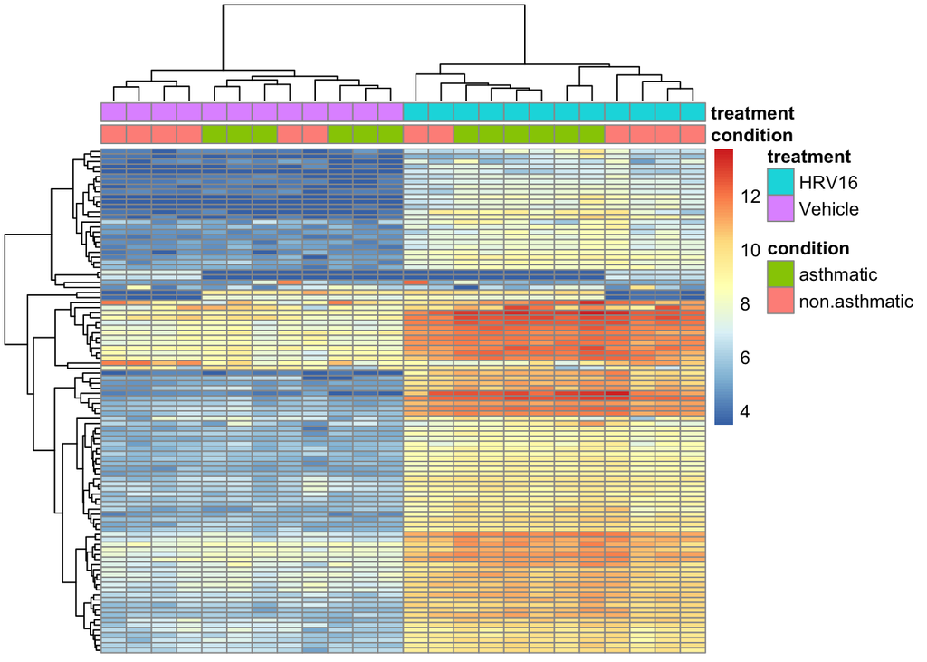

```r
library(pheatmap)
pheatmap(assay(vsd)[head(order(rv, decreasing=TRUE),100),],
         annotation_col=anno.col,
         show_rownames=FALSE, show_colnames=FALSE)
```